# H-G03-FINAL-PROJECT

Group-3

2026-04-20

# 1. Installing and Loading Libraries

First, we install and load the necessary libraries.

```r
packages <- c("readr", "ggplot2", "corrplot", "moments", "caret", "GGally", "rpart")

for(p in packages){
  if(!require(p, character.only = TRUE)){
    install.packages(p)
  }
  library(p, character.only = TRUE)
}
set.seed(123)
```

# 2. Data Collection

The dataset used in this project is a real-world stroke prediction dataset. It is used to predict whether a person may suffer from a stroke based on medical history, lifestyle, and demographic features.

- **Task Type**: Classification
- **Target Variable**: stroke
- **Dataset Source Link**: https://drive.google.com/uc?id=1PsCqVI9lfaZyrsc8JOhMzq5vzesBtDkh
- **Description**: The dataset includes columns such as age, gender, hypertension, heart disease, marital status, work type, residence type, average glucose level, BMI, smoking status, and stroke.

# 3. Loading Dataset

Loading the dataset from the provided Google Drive URL and inspect the first few rows to understand its structure.

```r
url <- "https://drive.google.com/uc?id=1PsCqVI9lfaZyrsc8JOhMzq5vzesBtDkh"

# Reading all possible variations of Not Available as NA
dataset <- read_csv(
  url,
  na = c("", "NA", "N/A", "n/a", "na", "NULL", "null"),
  show_col_types = FALSE
)

# Converting tibble to normal data frame for simple base R operations.
dataset <- as.data.frame(dataset)

# Viewing first rows
head(dataset)
```

```
##      id gender age hypertension heart_disease ever_married     work_type
## 1  9046   Male  67            0             1          Yes       Private
## 2 51676 Female  61            0             0          Yes Self-employed
## 3 31112   Male  80            0             1          Yes       Private
## 4 60182 Female  49            0             0          Yes       Private
## 5  1665 Female  79            1             0          Yes Self-employed
## 6 56669   Male  81            0             0          Yes       Private
##   Residence_type avg_glucose_level  bmi  smoking_status stroke
## 1          Urban            228.69 36.6 formerly smoked      1
## 2          Rural            202.21   NA    never smoked      1
## 3          Rural            105.92 32.5    never smoked      1
## 4          Urban            171.23 34.4          smokes      1
## 5          Rural            174.12 24.0    never smoked      1
## 6          Urban            186.21 29.0 formerly smoked      1
```

# 4. Cleaning Missing Value Format and Numerical Columns

This section makes sure that numerical columns are actually numeric and text values like `N/A` in BMI are treated as missing values.

```r
dataset$bmi <- trimws(as.character(dataset$bmi))
dataset$bmi[dataset$bmi %in% c("N/A", "NA", "n/a", "na", "NULL", "null", "")] <- NA

# Converting important columns to numeric type.
dataset$age <- suppressWarnings(as.numeric(as.character(dataset$age)))
dataset$avg_glucose_level <- suppressWarnings(as.numeric(as.character(dataset$avg_glucose_level)))
dataset$bmi <- suppressWarnings(as.numeric(dataset$bmi))
dataset$stroke <- suppressWarnings(as.numeric(as.character(dataset$stroke)))

cat("Missing BMI values before imputation:", sum(is.na(dataset$bmi)), "\n")
```

```
## Missing BMI values before imputation: 201
```

# 5. Dataset Shape and Structure

Here we check the dimensions and structure of the dataset to understand its features better.

```r
# Dimensions
dim(dataset)
```

```
## [1] 5110   12
```

```r
# Rows
nrow(dataset)
```

```
## [1] 5110
```

```r
# Columns
ncol(dataset)
```

```
## [1] 12
```

```r
# Dataset structure
str(dataset)
```

```
## 'data.frame':    5110 obs. of  12 variables:
##  $ id               : num  9046 51676 31112 60182 1665 ...
##  $ gender           : chr  "Male" "Female" "Male" "Female" ...
##  $ age              : num  67 61 80 49 79 81 74 69 59 78 ...
##  $ hypertension     : num  0 0 0 0 1 0 1 0 0 0 ...
##  $ heart_disease    : num  1 0 1 0 0 0 1 0 0 0 ...
##  $ ever_married     : chr  "Yes" "Yes" "Yes" "Yes" ...
##  $ work_type        : chr  "Private" "Self-employed" "Private" "Private" ...
##  $ Residence_type   : chr  "Urban" "Rural" "Rural" "Urban" ...
##  $ avg_glucose_level: num  229 202 106 171 174 ...
##  $ bmi              : num  36.6 NA 32.5 34.4 24 29 27.4 22.8 NA 24.2 ...
##  $ smoking_status   : chr  "formerly smoked" "never smoked" "never smoked" "smokes" ...
##  $ stroke           : num  1 1 1 1 1 1 1 1 1 1 ...
```

# 6. Identifying Numerical and Categorical Features

We will now identify the numerical and categorical features in the dataset.

```r
numeric_cols <- dataset[, sapply(dataset, is.numeric), drop = FALSE]

cat("Numerical Features:\n")
```

```
## Numerical Features:
```

```r
print(names(numeric_cols))
```

```
## [1] "id"                "age"               "hypertension"
## [4] "heart_disease"     "avg_glucose_level" "bmi"
## [7] "stroke"
```

```r
categorical_cols <- names(dataset)[sapply(dataset, function(x) is.character(x) | is.factor(x))]

cat("\nCategorical Features:\n")
```

```
##
## Categorical Features:
```

```r
print(categorical_cols)
```

```
## [1] "gender"         "ever_married"   "work_type"      "Residence_type"
## [5] "smoking_status"
```

# 7. Missing Values and Duplicate Checking

```r
# This checks how many missing values exist in every column before imputation.
colSums(is.na(dataset))
```

```
##                id            gender               age      hypertension
##                 0                 0                 0                 0
##     heart_disease      ever_married         work_type    Residence_type
##                 0                 0                 0                 0
## avg_glucose_level               bmi    smoking_status            stroke
##                 0               201                 0                 0
```

```r
# This checks if any duplicate rows exist.
sum(duplicated(dataset))
```

```
## [1] 0
```

# 8. Basic Descriptive Statistics

We compute basic summary statistics for numerical variables.

```r
# Summary of dataset
summary(dataset)
```

```
##        id           gender               age         hypertension
##  Min.   :   67   Length:5110        Min.   : 0.08   Min.   :0.00000
##  1st Qu.:17741   Class :character   1st Qu.:25.00   1st Qu.:0.00000
##  Median :36932   Mode  :character   Median :45.00   Median :0.00000
##  Mean   :36518                      Mean   :43.23   Mean   :0.09746
##  3rd Qu.:54682                      3rd Qu.:61.00   3rd Qu.:0.00000
##  Max.   :72940                      Max.   :82.00   Max.   :1.00000
##
##  heart_disease     ever_married        work_type         Residence_type
##  Min.   :0.00000   Length:5110        Length:5110        Length:5110
##  1st Qu.:0.00000   Class :character   Class :character   Class :character
##  Median :0.00000   Mode  :character   Mode  :character   Mode  :character
##  Mean   :0.05401
##  3rd Qu.:0.00000
##  Max.   :1.00000
##
##  avg_glucose_level      bmi        smoking_status         stroke
##  Min.   : 55.12    Min.   :10.30   Length:5110        Min.   :0.00000
##  1st Qu.: 77.25    1st Qu.:23.50   Class :character   1st Qu.:0.00000
##  Median : 91.89    Median :28.10   Mode  :character   Median :0.00000
##  Mean   :106.15    Mean   :28.89                      Mean   :0.04873
##  3rd Qu.:114.09    3rd Qu.:33.10                      3rd Qu.:0.00000
##  Max.   :271.74    Max.   :97.60                      Max.   :1.00000
##                    NA's   :201
```

```r
# Update numerical columns after conversion
numeric_cols <- dataset[, sapply(dataset, is.numeric), drop = FALSE]

# Mean
colMeans(numeric_cols, na.rm = TRUE)
```

```
##                id               age      hypertension     heart_disease
##      3.651783e+04      4.322661e+01      9.745597e-02      5.401174e-02
## avg_glucose_level               bmi            stroke
##      1.061477e+02      2.889324e+01      4.872798e-02
```

```r
# Median
apply(numeric_cols, 2, median, na.rm = TRUE)
```

```
##                id               age      hypertension     heart_disease
##         36932.000            45.000             0.000             0.000
## avg_glucose_level               bmi            stroke
##            91.885            28.100             0.000
```

```r
# Standard deviation
apply(numeric_cols, 2, sd, na.rm = TRUE)
```

```
##                id               age      hypertension     heart_disease
##      2.116172e+04      2.261265e+01      2.966067e-01      2.260630e-01
## avg_glucose_level               bmi            stroke
##      4.528356e+01      7.854067e+00      2.153199e-01
```

```r
# Variance
apply(numeric_cols, 2, var, na.rm = TRUE)
```

```
##                id               age      hypertension     heart_disease
##      4.478185e+08      5.113318e+02      8.797552e-02      5.110447e-02
## avg_glucose_level               bmi            stroke
##      2.050601e+03      6.168636e+01      4.636264e-02
```

```r
# Minimum values
apply(numeric_cols, 2, min, na.rm = TRUE)
```

```
##                id               age      hypertension     heart_disease
##             67.00              0.08              0.00              0.00
## avg_glucose_level               bmi            stroke
##             55.12             10.30              0.00
```

```r
# Maximum values
apply(numeric_cols, 2, max, na.rm = TRUE)
```

```
##                id               age      hypertension     heart_disease
##          72940.00             82.00              1.00              1.00
## avg_glucose_level               bmi            stroke
##            271.74             97.60              1.00
```

```r
# Quartiles
apply(numeric_cols, 2, quantile, na.rm = TRUE)
```

```
##            id   age hypertension heart_disease avg_glucose_level  bmi stroke
## 0%      67.00  0.08            0             0            55.120 10.3      0
## 25%  17741.25 25.00            0             0            77.245 23.5      0
## 50%  36932.00 45.00            0             0            91.885 28.1      0
## 75%  54682.00 61.00            0             0           114.090 33.1      0
## 100% 72940.00 82.00            1             1           271.740 97.6      1
```

```r
# Count non-missing values
colSums(!is.na(dataset))
```

```
##                id            gender               age      hypertension
##              5110              5110              5110              5110
##     heart_disease      ever_married         work_type    Residence_type
##              5110              5110              5110              5110
## avg_glucose_level               bmi    smoking_status            stroke
##              5110              4909              5110              5110
```

# 9. Correlation Matrix and Heatmap

```r
eda_numeric <- dataset[, c("age", "avg_glucose_level", "bmi", "stroke")]
cor_matrix <- cor(eda_numeric, use = "complete.obs")
print(cor_matrix)
```

```
##                         age avg_glucose_level        bmi     stroke
## age               1.0000000         0.2358382 0.33339800 0.23233086
## avg_glucose_level 0.2358382         1.0000000 0.17550218 0.13893586
## bmi               0.3333980         0.1755022 1.00000000 0.04237366
## stroke            0.2323309         0.1389359 0.04237366 1.00000000
```

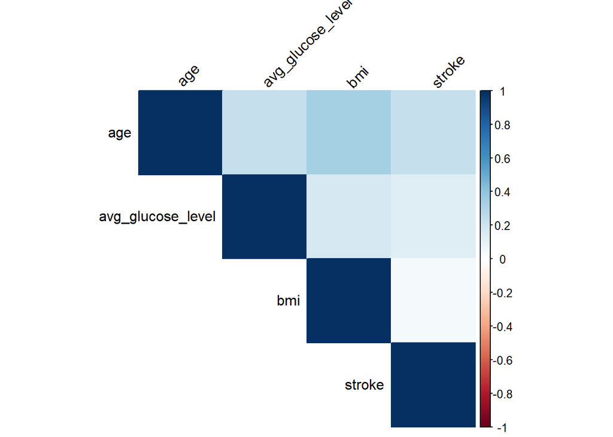

```r
# Correlation Heatmap
corrplot(cor_matrix, method = "color", type = "upper", tl.col = "black", tl.srt = 45)
```

# 10. Histograms for Relevant Numerical Variables

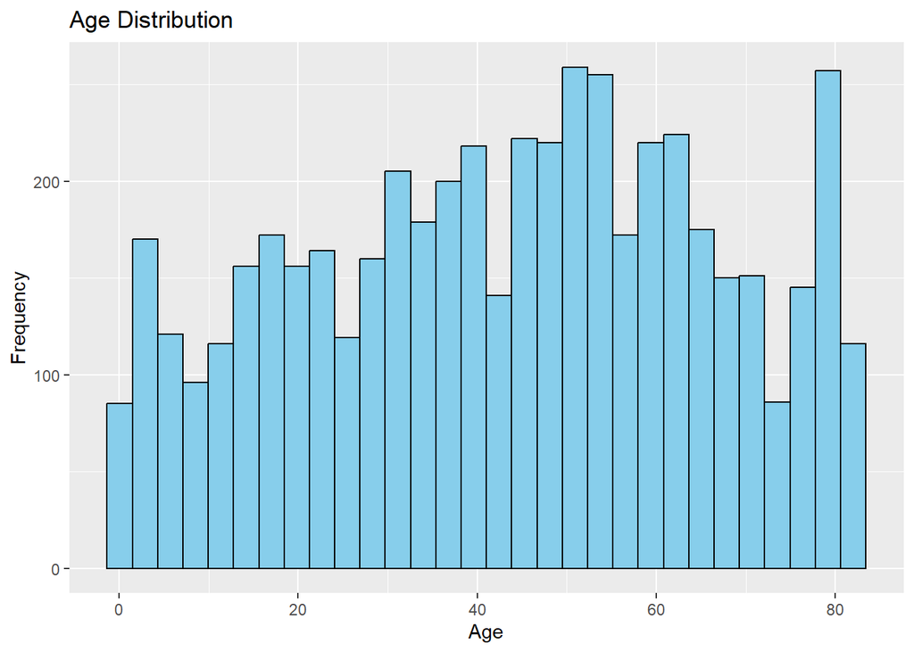

```r
# Age Histogram
ggplot(dataset, aes(x = age)) +
  geom_histogram(bins = 30, fill = "skyblue", color = "black") +
  labs(title = "Age Distribution", x = "Age", y = "Frequency")
```

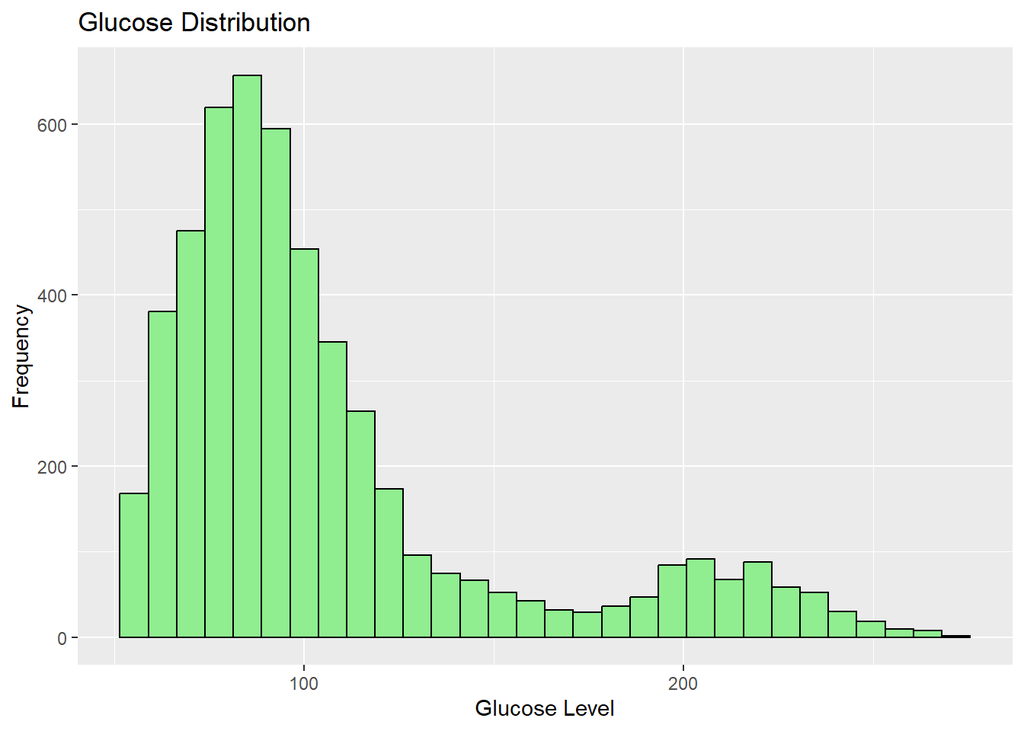

```r
# Glucose Histogram
ggplot(dataset, aes(x = avg_glucose_level)) +
  geom_histogram(bins = 30, fill = "lightgreen", color = "black") +
  labs(title = "Glucose Distribution", x = "Glucose Level", y = "Frequency")
```

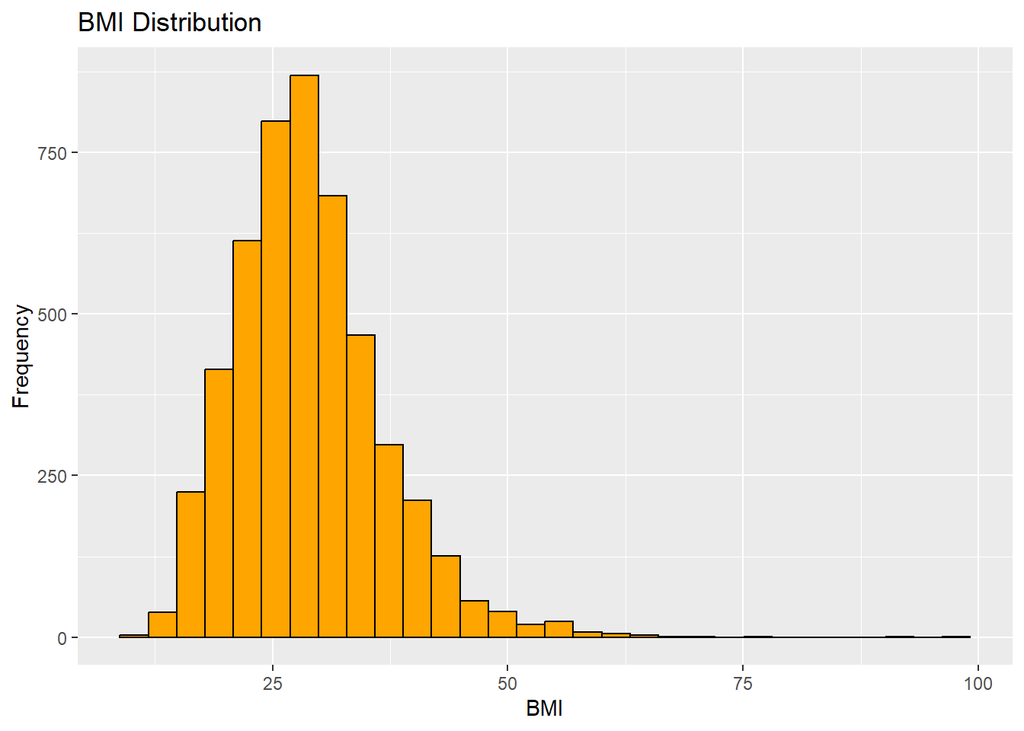

```r
# BMI Histogram
# Missing BMI values are excluded only from this plot.
ggplot(subset(dataset, !is.na(bmi)), aes(x = bmi)) +
  geom_histogram(bins = 30, fill = "orange", color = "black") +
  labs(title = "BMI Distribution", x = "BMI", y = "Frequency")
```

# 11. Frequency Tables and Bar Charts for Categorical Variables

```r
for(col in categorical_cols){
  cat("\nFrequency of", col, ":\n")
  print(table(dataset[[col]]))
}
```

```
##
## Frequency of gender :
##
## Female   Male  Other
##   2994   2115      1
##
## Frequency of ever_married :
##
##   No  Yes
## 1757 3353
##
## Frequency of work_type :
##
##      children      Govt_job  Never_worked       Private Self-employed
##           687           657            22          2925           819
##
## Frequency of Residence_type :
##
## Rural Urban
##  2514  2596
##
## Frequency of smoking_status :
##
## formerly smoked    never smoked          smokes         Unknown
##             885            1892             789            1544
```

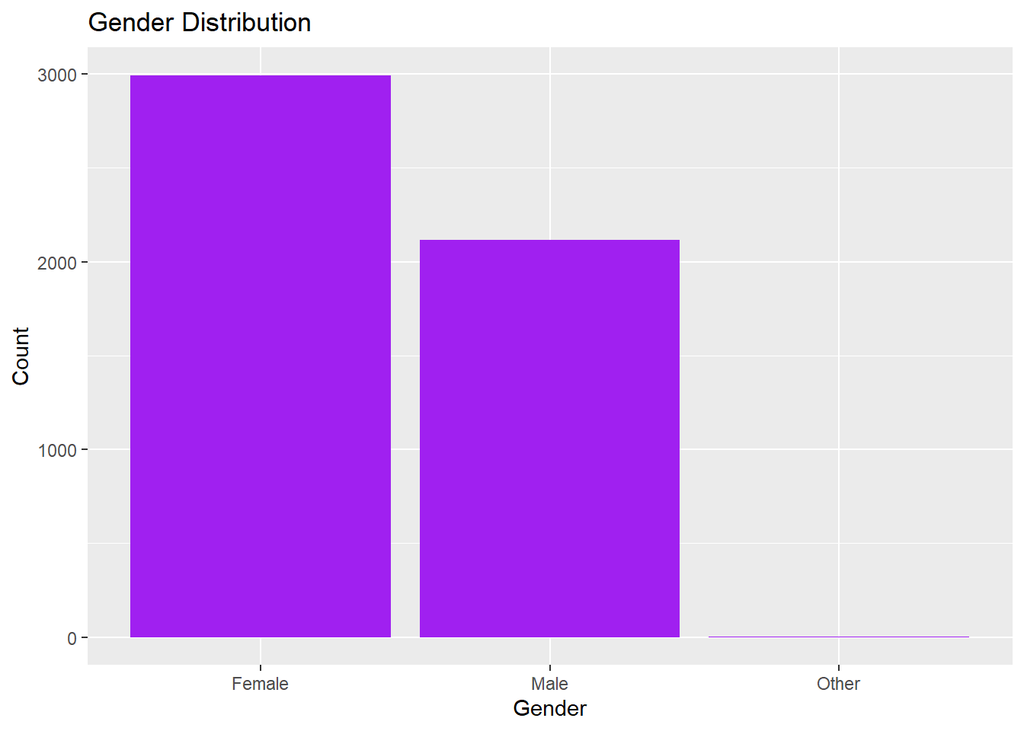

```r
# Gender Bar Chart
ggplot(dataset, aes(x = gender)) +
  geom_bar(fill = "purple") +
  labs(title = "Gender Distribution", x = "Gender", y = "Count")
```

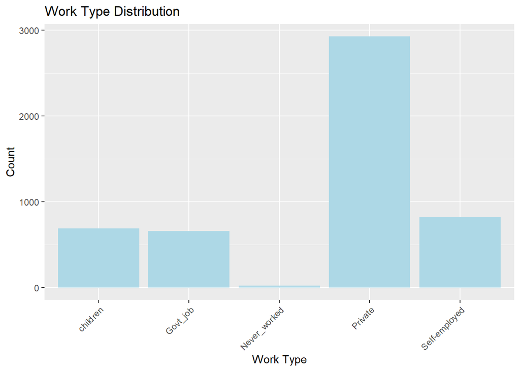

```r
# Work Type Bar Chart
ggplot(dataset, aes(x = work_type)) +
  geom_bar(fill = "lightblue") +
  labs(title = "Work Type Distribution", x = "Work Type", y = "Count") +
  theme(axis.text.x = element_text(angle = 45, hjust = 1))
```

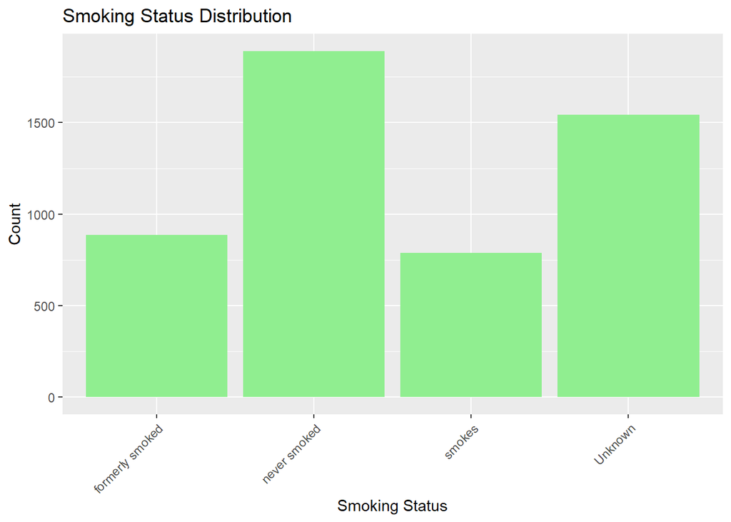

```r
# Smoking Status Bar Chart
ggplot(dataset, aes(x = smoking_status)) +
  geom_bar(fill = "lightgreen") +
  labs(title = "Smoking Status Distribution", x = "Smoking Status", y = "Count") +
  theme(axis.text.x = element_text(angle = 45, hjust = 1))
```

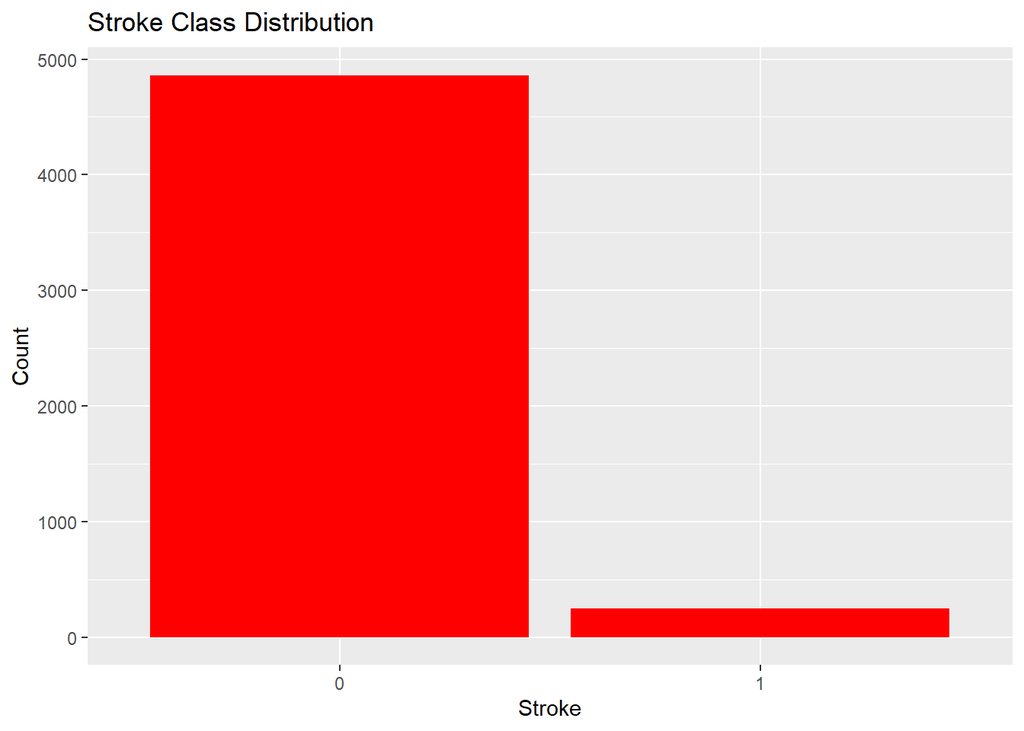

```r
# Stroke Bar Chart
ggplot(dataset, aes(x = factor(stroke))) +
  geom_bar(fill = "red") +
  labs(title = "Stroke Class Distribution", x = "Stroke", y = "Count")
```

# 12. Pair Plot

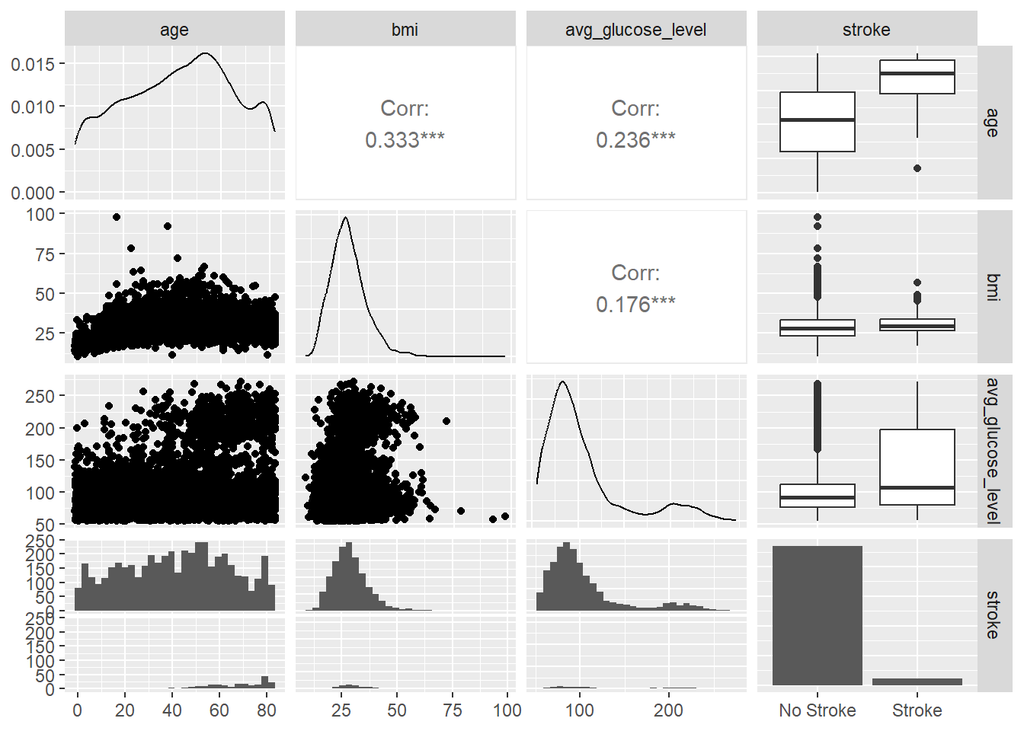

```r
pair_data <- dataset[, c("age", "bmi", "avg_glucose_level", "stroke")]
pair_data$stroke <- factor(pair_data$stroke, levels = c(0, 1), labels = c("No Stroke", "Stroke"))
pair_data <- na.omit(pair_data)

# Creating a pair plot to visualize relationships between selected variables
GGally::ggpairs(pair_data)
```

# 13. Core Data Analysis

This section gives a short numerical summary of the target variable and key health-related variables.

```r
# Stroke count shows class balance or imbalance.
stroke_count <- table(dataset$stroke)
stroke_count
```

```
##
##    0    1
## 4861  249
```

```r
# Stroke percentage shows how much of the dataset belongs to each class.
prop.table(stroke_count) * 100
```

```
##
##         0         1
## 95.127202  4.872798
```

```r
# Comparing average age, BMI, and glucose level between stroke and non-stroke groups.
aggregate(cbind(age, bmi, avg_glucose_level) ~ stroke,
          data = dataset,
          FUN = mean,
          na.rm = TRUE)
```

```
##   stroke      age      bmi avg_glucose_level
## 1      0 41.76045 28.82306          104.0037
## 2      1 67.71292 30.47129          134.5714
```

# 14. Bivariate Analysis

We generate bivariate visualizations for relationships between variables.

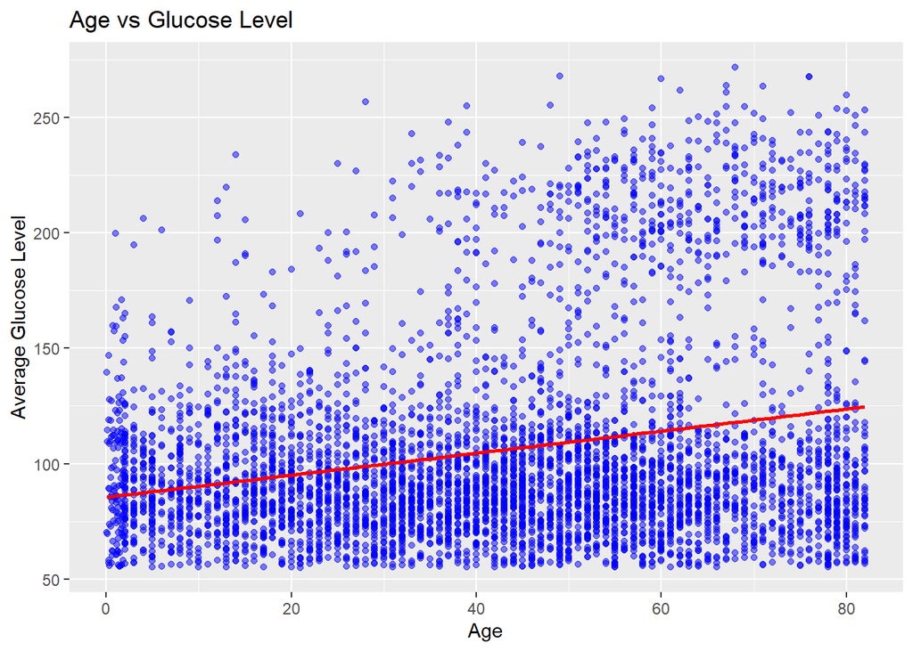

```r
# Age vs Glucose Scatter Plot with trend line
ggplot(dataset, aes(x = age, y = avg_glucose_level)) +
  geom_point(color = "blue", alpha = 0.5) +
  geom_smooth(method = "lm", se = FALSE, color = "red") +
  labs(title = "Age vs Glucose Level", x = "Age", y = "Average Glucose Level")
```

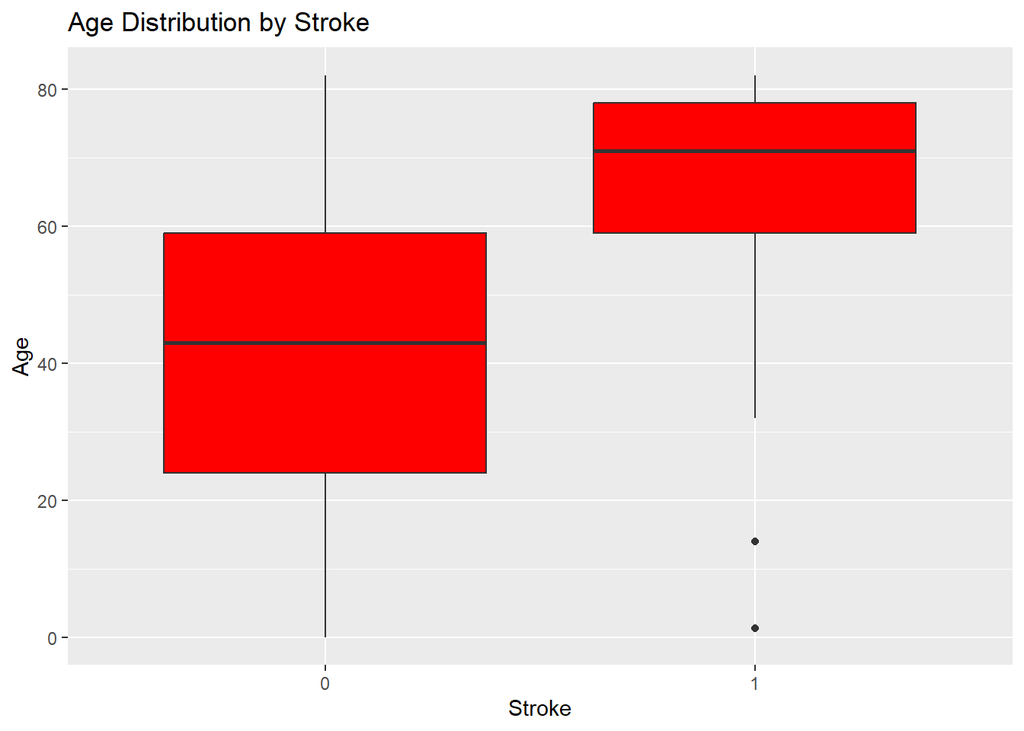

```r
# Age vs Stroke Boxplot
ggplot(dataset, aes(x = factor(stroke), y = age)) +
  geom_boxplot(fill = "red") +
  labs(title = "Age Distribution by Stroke", x = "Stroke", y = "Age")
```

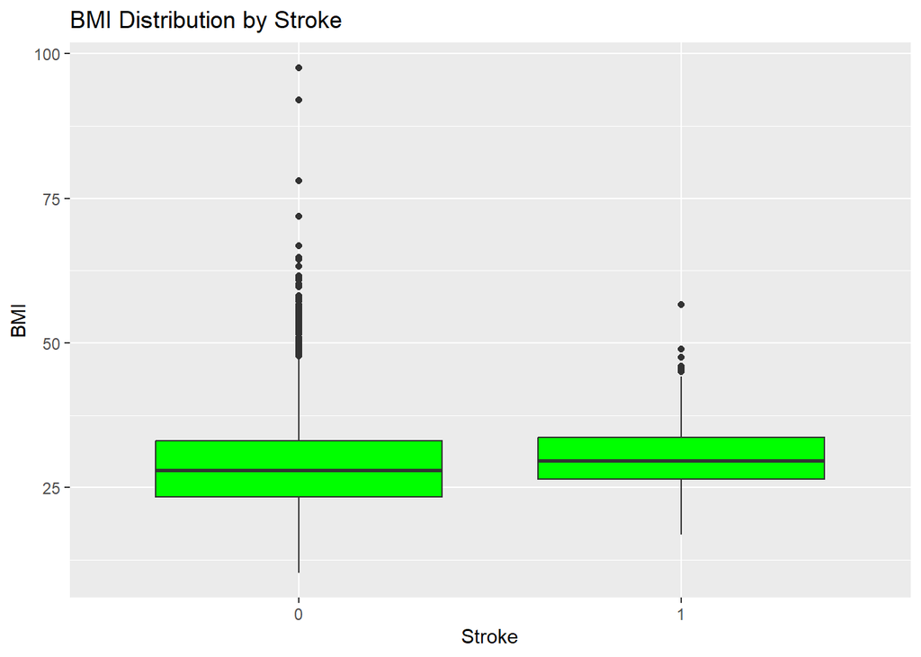

```r
# BMI vs Stroke Boxplot
ggplot(subset(dataset, !is.na(bmi)), aes(x = factor(stroke), y = bmi)) +
  geom_boxplot(fill = "green") +
  labs(title = "BMI Distribution by Stroke", x = "Stroke", y = "BMI")
```

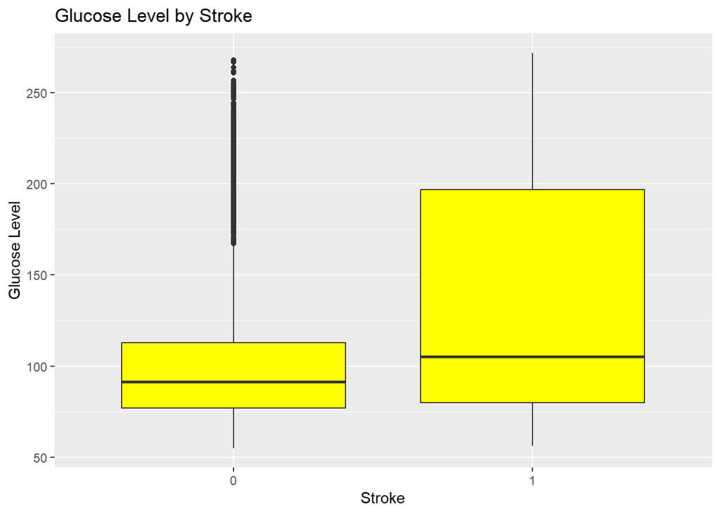

```r
# Glucose vs Stroke Boxplot
ggplot(dataset, aes(x = factor(stroke), y = avg_glucose_level)) +
  geom_boxplot(fill = "yellow") +
  labs(title = "Glucose Level by Stroke", x = "Stroke", y = "Glucose Level")
```

# 15. Categorical Analysis

We explore stroke distribution across categorical features like gender, work type, and smoking status.

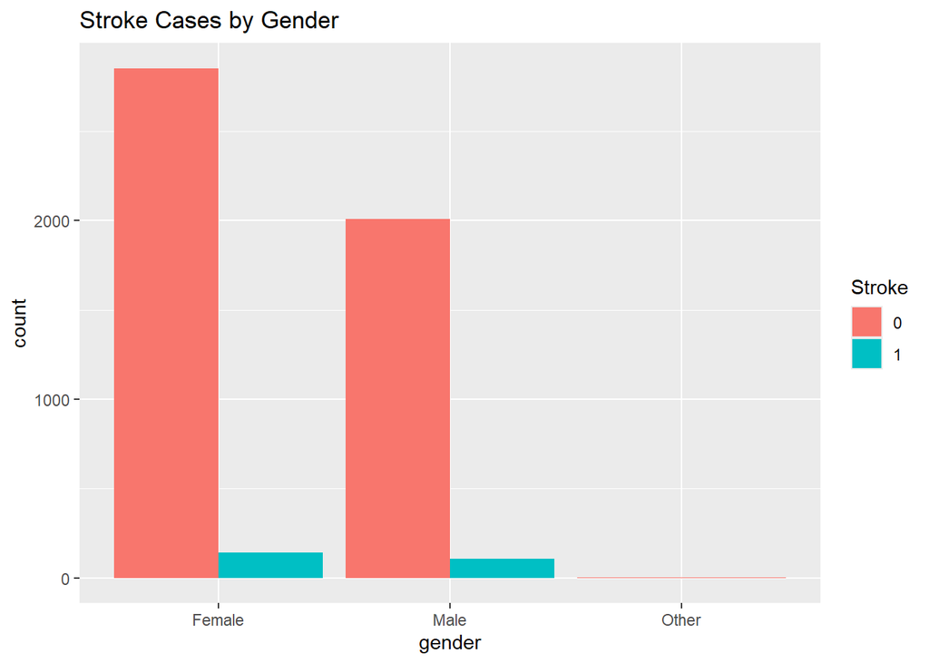

```r
# Stroke by Gender
ggplot(dataset, aes(x = gender, fill = factor(stroke))) +
  geom_bar(position = "dodge") +
  labs(title = "Stroke Cases by Gender", fill = "Stroke")
```

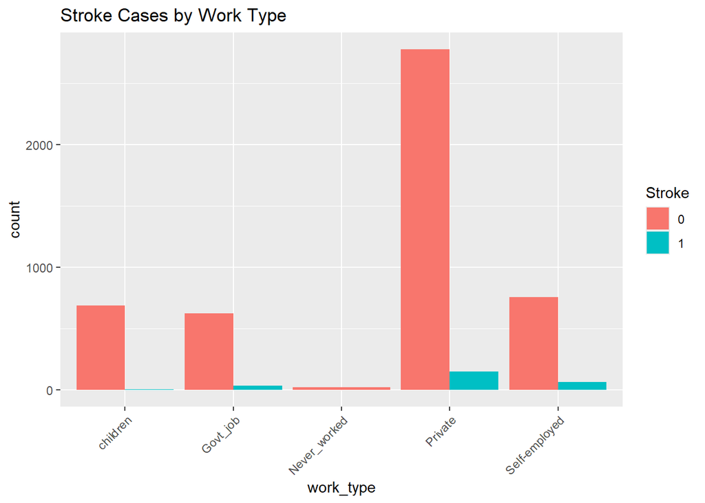

```r
# Stroke by Work Type
ggplot(dataset, aes(x = work_type, fill = factor(stroke))) +
  geom_bar(position = "dodge") +
  labs(title = "Stroke Cases by Work Type", fill = "Stroke") +
  theme(axis.text.x = element_text(angle = 45, hjust = 1))
```

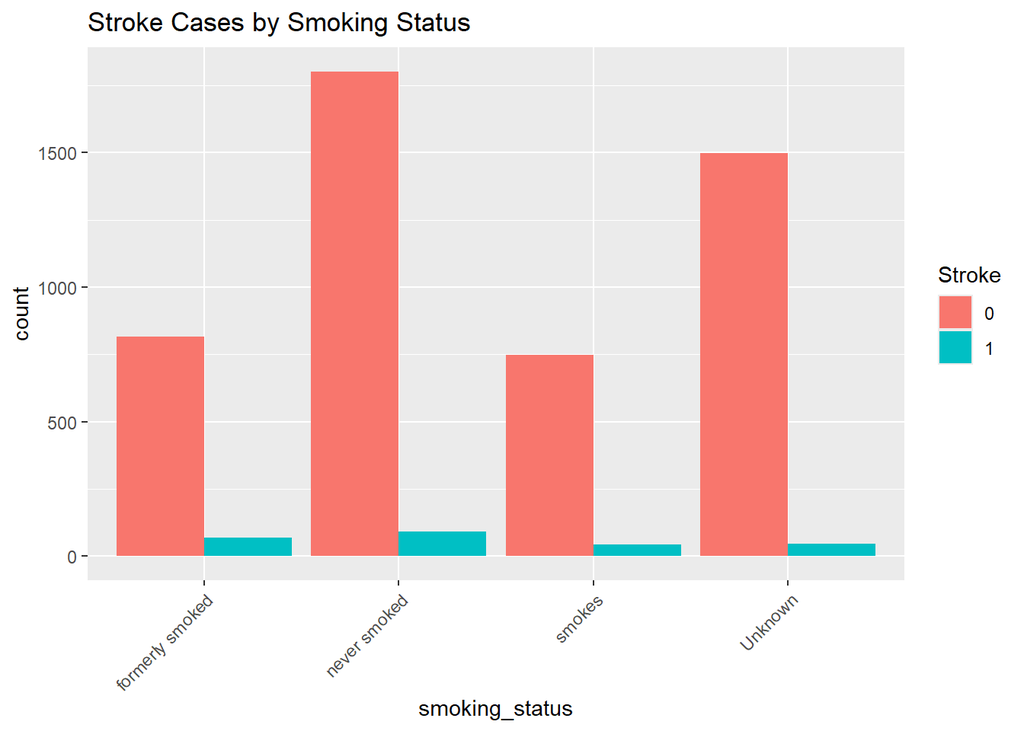

```r
# Stroke by Smoking Status
ggplot(dataset, aes(x = smoking_status, fill = factor(stroke))) +
  geom_bar(position = "dodge") +
  labs(title = "Stroke Cases by Smoking Status", fill = "Stroke") +
  theme(axis.text.x = element_text(angle = 45, hjust = 1))
```

# 16. Pie Chart Visualization

We generate pie charts to represent the distribution of gender and stroke.

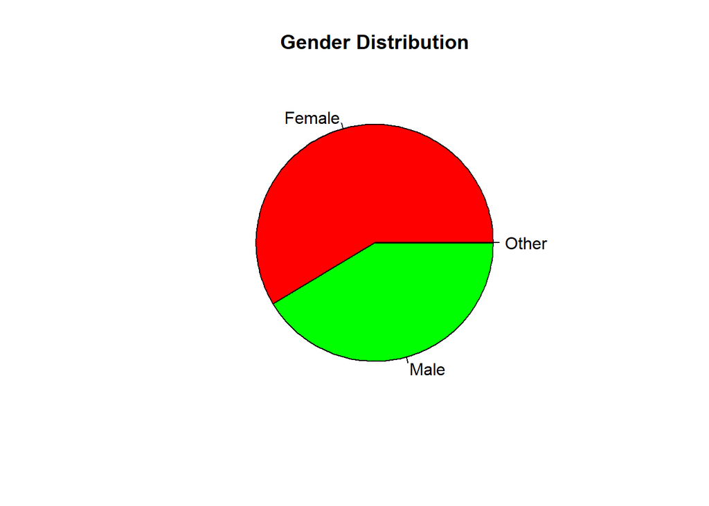

```r
# Gender Pie Chart
gender_counts <- table(dataset$gender)
pie(gender_counts,
    main = "Gender Distribution",
    col = rainbow(length(gender_counts)))
```

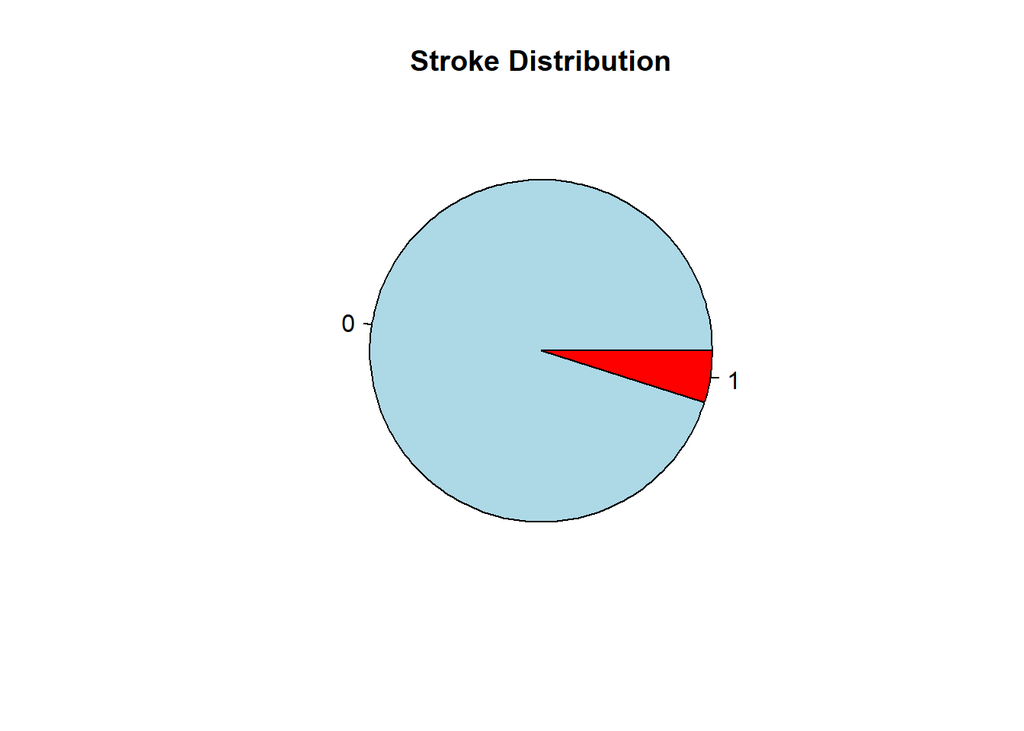

```r
# Stroke Pie Chart
stroke_counts <- table(dataset$stroke)
pie(stroke_counts,
    main = "Stroke Distribution",
    col = c("lightblue", "red"))
```

# 17. Interpretations from EDA

### Correlation Analysis

The correlation heatmap shows the relationships among the selected numerical variables. Among the numerical variables, **age** shows an important positive relationship with the target variable **stroke**. This suggests that stroke cases are more common among older patients.

### Distribution of Key Features

The histogram for **age** shows the age distribution of patients. The **BMI** and **average glucose level** histograms show the spread of health-related numerical variables. These variables are useful for this project because they describe physical and medical conditions that may be connected with stroke risk.

### Pair Plot and Bivariate Plots

The pair plot and boxplots help compare age, BMI, and average glucose level between stroke and non-stroke cases. The stroke class distribution also shows that the dataset is imbalanced, because non-stroke cases are much higher than stroke cases. This imbalance is very important to remember when interpreting model accuracy, precision, recall, and F1-score.

# 18. Data Preprocessing: Handling Missing Values

```r
# Rechecking missing values before preproceessing
colSums(is.na(dataset))
```

```
##                id            gender               age      hypertension
##                 0                 0                 0                 0
##     heart_disease      ever_married         work_type    Residence_type
##                 0                 0                 0                 0
## avg_glucose_level               bmi    smoking_status            stroke
##                 0               201                 0                 0
```

```r
# Replacing missing BMI values with the median BMI because BMI has outliers.
dataset$bmi[is.na(dataset$bmi)] <- median(dataset$bmi, na.rm = TRUE)

# Checking missing values after handling.
colSums(is.na(dataset))
```

```
##                id            gender               age      hypertension
##                 0                 0                 0                 0
##     heart_disease      ever_married         work_type    Residence_type
##                 0                 0                 0                 0
## avg_glucose_level               bmi    smoking_status            stroke
##                 0                 0                 0                 0
```

# 19. Outlier Detection and Handling using IQR Method

Detecting and handling outliers in BMI using the IQR method.

```r
Q1 <- quantile(dataset$bmi, 0.25, na.rm = TRUE)
Q3 <- quantile(dataset$bmi, 0.75, na.rm = TRUE)

IQR_value <- Q3 - Q1

lower_bound <- Q1 - 1.5 * IQR_value
upper_bound <- Q3 + 1.5 * IQR_value

# Values below lower bound are being replaced by lower bound, and values above upper bound are replaced by upper bound.
dataset$bmi[dataset$bmi < lower_bound] <- lower_bound
dataset$bmi[dataset$bmi > upper_bound] <- upper_bound
```

# 20. Feature Engineering

```r
# Creating Age Group
dataset$age_group <- cut(dataset$age,
                         breaks = c(-Inf, 30, 40, 50, 60, Inf),
                         labels = c("Young", "Middle-Aged", "Older", "Senior", "Elder"))

# Creating BMI Categories
dataset$bmi_category <- cut(dataset$bmi,
                            breaks = c(-Inf, 18.5, 24.9, 29.9, Inf),
                            labels = c("Underweight", "Normal", "Overweight", "Obese"))

head(dataset)
```

```
##      id gender age hypertension heart_disease ever_married     work_type
## 1  9046   Male  67            0             1          Yes       Private
## 2 51676 Female  61            0             0          Yes Self-employed
## 3 31112   Male  80            0             1          Yes       Private
## 4 60182 Female  49            0             0          Yes       Private
## 5  1665 Female  79            1             0          Yes Self-employed
## 6 56669   Male  81            0             0          Yes       Private
##   Residence_type avg_glucose_level  bmi  smoking_status stroke age_group
## 1          Urban            228.69 36.6 formerly smoked      1     Elder
## 2          Rural            202.21 28.1    never smoked      1     Elder
## 3          Rural            105.92 32.5    never smoked      1     Elder
## 4          Urban            171.23 34.4          smokes      1     Older
## 5          Rural            174.12 24.0    never smoked      1     Elder
## 6          Urban            186.21 29.0 formerly smoked      1     Elder
##   bmi_category
## 1        Obese
## 2   Overweight
## 3        Obese
## 4        Obese
## 5       Normal
## 6   Overweight
```

# 21. Skewness Checking

```r
# Checking skewness of important continuous variables.
skewness_values <- apply(dataset[, c("age", "bmi", "avg_glucose_level")], 2, skewness, na.rm = TRUE)
skewness_values
```

```
##               age               bmi avg_glucose_level
##        -0.1370191         0.4491157         1.5718223
```

```r
# A log version of glucose is checked only for comparison.
log_glucose_temp <- log(dataset$avg_glucose_level + 1)
skewness(log_glucose_temp, na.rm = TRUE)
```

```
## [1] 0.8892086
```

# 22. Mode Calculation

We calculate the mode for categorical variables.

```r
# Updating categorical columns after creating age_group and bmi_category.
categorical_cols <- names(dataset)[sapply(dataset, function(x) is.character(x) | is.factor(x))]

mode_function <- function(x){
  ux <- unique(x)
  ux[which.max(tabulate(match(x, ux)))]
}

for(col in categorical_cols){
  cat("\nMode of", col, ":\n")
  print(mode_function(dataset[[col]]))
}
```

```
##
## Mode of gender :
## [1] "Female"
##
## Mode of ever_married :
## [1] "Yes"
##
## Mode of work_type :
## [1] "Private"
##
## Mode of Residence_type :
## [1] "Urban"
##
## Mode of smoking_status :
## [1] "never smoked"
##
## Mode of age_group :
## [1] Young
## Levels: Young Middle-Aged Older Senior Elder
##
## Mode of bmi_category :
## [1] Obese
## Levels: Underweight Normal Overweight Obese
```

# 23. Skewness of Numeric Variables

We compute the skewness of the numerical variables.

```r
numeric_cols <- dataset[, sapply(dataset, is.numeric), drop = FALSE]
apply(numeric_cols, 2, skewness, na.rm = TRUE)
```

```
##                id               age      hypertension     heart_disease
##       -0.01990713       -0.13701909        2.71459451        3.94608519
## avg_glucose_level               bmi            stroke
##        1.57182230        0.44911568        4.19205348
```

# 24. Encoding Categorical Variables

We encode categorical variables as numeric values so that they can be used by the classification model.

```r
# These columns are categorical, so we are converting them into numeric codes for modeling.
dataset$gender <- as.numeric(as.factor(dataset$gender))
dataset$ever_married <- as.numeric(as.factor(dataset$ever_married))
dataset$work_type <- as.numeric(as.factor(dataset$work_type))
dataset$Residence_type <- as.numeric(as.factor(dataset$Residence_type))
dataset$smoking_status <- as.numeric(as.factor(dataset$smoking_status))

# Encoding engineered categorical features too.
dataset$age_group <- as.numeric(as.factor(dataset$age_group))
dataset$bmi_category <- as.numeric(as.factor(dataset$bmi_category))

numeric_cols <- dataset[, sapply(dataset, is.numeric), drop = FALSE]
head(dataset)
```

```
##      id gender age hypertension heart_disease ever_married work_type
## 1  9046      2  67            0             1            2         4
## 2 51676      1  61            0             0            2         5
## 3 31112      2  80            0             1            2         4
## 4 60182      1  49            0             0            2         4
## 5  1665      1  79            1             0            2         5
## 6 56669      2  81            0             0            2         4
##   Residence_type avg_glucose_level  bmi smoking_status stroke age_group
## 1              2            228.69 36.6              1      1         5
## 2              1            202.21 28.1              2      1         5
## 3              1            105.92 32.5              2      1         5
## 4              2            171.23 34.4              3      1         3
## 5              1            174.12 24.0              2      1         5
## 6              2            186.21 29.0              1      1         5
##   bmi_category
## 1            4
## 2            3
## 3            4
## 4            4
## 5            2
## 6            3
```

# 25. Feature Selection

We remove the id column as it does not contribute to prediction.

```r
dataset$id <- NULL

head(dataset)
```

```
##   gender age hypertension heart_disease ever_married work_type Residence_type
## 1      2  67            0             1            2         4              2
## 2      1  61            0             0            2         5              1
## 3      2  80            0             1            2         4              1
## 4      1  49            0             0            2         4              2
## 5      1  79            1             0            2         5              1
## 6      2  81            0             0            2         4              2
##   avg_glucose_level  bmi smoking_status stroke age_group bmi_category
## 1            228.69 36.6              1      1         5            4
## 2            202.21 28.1              2      1         5            3
## 3            105.92 32.5              2      1         5            4
## 4            171.23 34.4              3      1         3            4
## 5            174.12 24.0              2      1         5            2
## 6            186.21 29.0              1      1         5            3
```

# 26. Correlation Analysis after Preprocessing

We analyze the correlation matrix and correlate with the stroke variable.

```r
cor_matrix <- cor(dataset[, sapply(dataset, is.numeric)], use = "complete.obs")
print(cor_matrix)
```

```
##                          gender         age hypertension heart_disease
## gender             1.0000000000 -0.02820177  0.020994335   0.085446816
## age               -0.0282017726  1.00000000  0.276397628   0.263795916
## hypertension       0.0209943351  0.27639763  1.000000000   0.108306076
## heart_disease      0.0854468161  0.26379592  0.108306076   1.000000000
## ever_married      -0.0310047617  0.67912500  0.164243093   0.114644062
## work_type         -0.0704755275  0.53776470  0.128644704   0.098359444
## Residence_type    -0.0067376829  0.01418001 -0.007913455   0.003092021
## avg_glucose_level  0.0551800388  0.23817111  0.174473811   0.161857332
## bmi               -0.0249705132  0.35109652  0.154519827   0.044653967
## smoking_status     0.0379565347 -0.37584521 -0.129012034  -0.064671231
## stroke             0.0089288663  0.24525735  0.127903823   0.134913997
## age_group          0.0006657571  0.95470145  0.277277199   0.262357392
## bmi_category       0.0196638014  0.42677675  0.152405627   0.080293419
##                   ever_married    work_type Residence_type avg_glucose_level
## gender             -0.03100476 -0.070475528   -0.006737683       0.055180039
## age                 0.67912500  0.537764699    0.014180009       0.238171114
## hypertension        0.16424309  0.128644704   -0.007913455       0.174473811
## heart_disease       0.11464406  0.098359444    0.003092021       0.161857332
## ever_married        1.00000000  0.425595308    0.006260950       0.155067787
## work_type           0.42559531  1.000000000   -0.003158526       0.093344976
## Residence_type      0.00626095 -0.003158526    1.000000000      -0.004945652
## avg_glucose_level   0.15506779  0.093344976   -0.004945652       1.000000000
## bmi                 0.35678008  0.354278829    0.004205307       0.175822470
## smoking_status     -0.30369450 -0.338481670    0.004655982      -0.097732229
## stroke              0.10833974  0.084339118    0.015457965       0.131945441
## age_group           0.64285658  0.412172862    0.008987969       0.244863056
## bmi_category        0.39916031  0.397330270   -0.006816993       0.163536154
##                            bmi smoking_status       stroke     age_group
## gender            -0.024970513    0.037956535  0.008928866  0.0006657571
## age                0.351096523   -0.375845210  0.245257346  0.9547014518
## hypertension       0.154519827   -0.129012034  0.127903823  0.2772771985
## heart_disease      0.044653967   -0.064671231  0.134913997  0.2623573917
## ever_married       0.356780084   -0.303694495  0.108339742  0.6428565840
## work_type          0.354278829   -0.338481670  0.084339118  0.4121728624
## Residence_type     0.004205307    0.004655982  0.015457965  0.0089879688
## avg_glucose_level  0.175822470   -0.097732229  0.131945441  0.2448630558
## bmi                1.000000000   -0.248286437  0.042699992  0.2934356194
## smoking_status    -0.248286437    1.000000000 -0.066392745 -0.3137559786
## stroke             0.042699992   -0.066392745  1.000000000  0.2349173956
## age_group          0.293435619   -0.313755979  0.234917396  1.0000000000
## bmi_category       0.886299008   -0.277592199  0.059200751  0.3621258122
##                   bmi_category
## gender             0.019663801
## age                0.426776746
## hypertension       0.152405627
## heart_disease      0.080293419
## ever_married       0.399160312
## work_type          0.397330270
## Residence_type    -0.006816993
## avg_glucose_level  0.163536154
## bmi                0.886299008
## smoking_status    -0.277592199
## stroke             0.059200751
## age_group          0.362125812
## bmi_category       1.000000000
```

```r
# Correlation with stroke variable
cor_matrix["stroke", ]
```

```
##            gender               age      hypertension     heart_disease
##       0.008928866       0.245257346       0.127903823       0.134913997
##      ever_married         work_type    Residence_type avg_glucose_level
##       0.108339742       0.084339118       0.015457965       0.131945441
##               bmi    smoking_status            stroke         age_group
##       0.042699992      -0.066392745       1.000000000       0.234917396
##      bmi_category
##       0.059200751
```

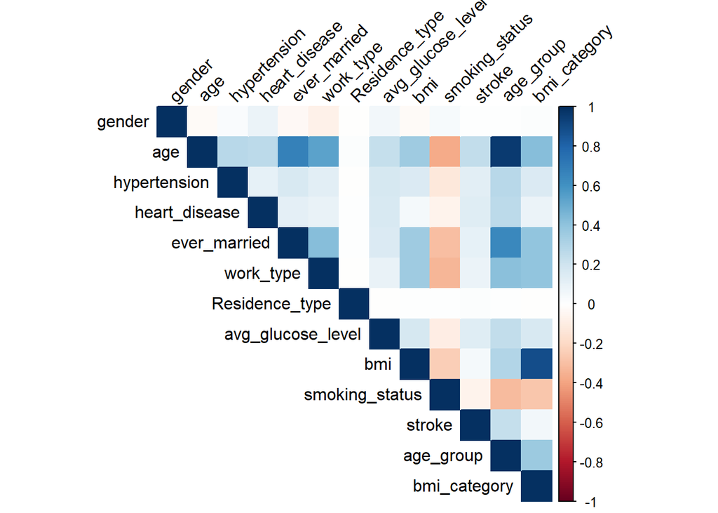

```r
# Correlation Heatmap
corrplot(cor_matrix,
         method = "color",
         type = "upper",
         tl.col = "black",
         tl.srt = 45)
```

# 27. Train-Test Split

We split the dataset into training and testing sets. The training set is used to train the model, and the testing set is used to evaluate the model.

```r
# Converting target variable into factor for classification evaluation.
dataset$stroke <- factor(dataset$stroke,
                         levels = c(0, 1),
                         labels = c("No_Stroke", "Stroke"))

# 80% data is used for training and 20% data is used for testing.
train_index <- createDataPartition(dataset$stroke, p = 0.80, list = FALSE)

train_data <- dataset[train_index, ]
test_data <- dataset[-train_index, ]

# Check training and testing data size
dim(train_data)
```

```
## [1] 4089   13
```

```r
dim(test_data)
```

```
## [1] 1021   13
```

# 28. Data Scaling

We scale only the numerical predictor variables. The target variable is not scaled.

```r
# Scaling is done after train-test split to avoid data leakage.
numeric_predictors <- names(train_data)[sapply(train_data, is.numeric)]

preprocess_values <- preProcess(train_data[, numeric_predictors], method = c("center", "scale"))

train_data[, numeric_predictors] <- predict(preprocess_values, train_data[, numeric_predictors])
test_data[, numeric_predictors] <- predict(preprocess_values, test_data[, numeric_predictors])

head(train_data)
```

```
##       gender       age hypertension heart_disease ever_married work_type
## 1  1.2003516 1.0472463   -0.3324315     4.2133761    0.7175511 0.3967603
## 3  1.2003516 1.6225581   -0.3324315     4.2133761    0.7175511 0.3967603
## 4 -0.8312037 0.2506609   -0.3324315    -0.2372813    0.7175511 0.3967603
## 5 -0.8312037 1.5783033    3.0074026    -0.2372813    0.7175511 1.1797490
## 6  1.2003516 1.6668128   -0.3324315    -0.2372813    0.7175511 0.3967603
## 7  1.2003516 1.3570296    3.0074026     4.2133761    0.7175511 0.3967603
##   Residence_type avg_glucose_level         bmi smoking_status stroke  age_group
## 1      0.9783464        2.69291464  1.09293254     -1.4571006 Stroke 1.29657776
## 3     -1.0218828       -0.01576208  0.52024155     -0.5387769 Stroke 1.29657776
## 4      0.9783464        1.42517362  0.78563494      0.3795469 Stroke 0.04129033
## 5     -1.0218828        1.48893575 -0.66704466     -0.5387769 Stroke 1.29657776
## 6      0.9783464        1.75567763  0.03135899     -1.4571006 Stroke 1.29657776
## 7     -1.0218828       -0.80628002 -0.19213018     -0.5387769 Stroke 1.29657776
##   bmi_category
## 1  1.051946285
## 3  1.051946285
## 4  1.051946285
## 5 -1.066452316
## 6 -0.007253016
## 7 -0.007253016
```

# 29. Model Building: Logistic Regression

Logistic Regression is used because the target variable has two classes: Stroke and No Stroke.

```r
logistic_model <- glm(stroke ~ ., data = train_data, family = binomial)

summary(logistic_model)
```

```
##
## Call:
## glm(formula = stroke ~ ., family = binomial, data = train_data)
##
## Coefficients:
##                   Estimate Std. Error z value Pr(>|z|)
## (Intercept)       -3.91760    0.15169 -25.827  < 2e-16 ***
## gender             0.06082    0.07734   0.786  0.43160
## age                1.52981    0.30306   5.048 4.47e-07 ***
## hypertension       0.07413    0.05632   1.316  0.18805
## heart_disease      0.07328    0.04799   1.527  0.12681
## ever_married      -0.09501    0.11829  -0.803  0.42187
## work_type         -0.10995    0.10263  -1.071  0.28406
## Residence_type     0.08418    0.07695   1.094  0.27399
## avg_glucose_level  0.19354    0.06013   3.218  0.00129 **
## bmi                0.09883    0.17101   0.578  0.56332
## smoking_status     0.02884    0.08007   0.360  0.71874
## age_group          0.05490    0.31693   0.173  0.86248
## bmi_category      -0.11105    0.17681  -0.628  0.52996
## ---
## Signif. codes:  0 '***' 0.001 '**' 0.01 '*' 0.05 '.' 0.1 ' ' 1
##
## (Dispersion parameter for binomial family taken to be 1)
##
##     Null deviance: 1597.1  on 4088  degrees of freedom
## Residual deviance: 1290.8  on 4076  degrees of freedom
## AIC: 1316.8
##
## Number of Fisher Scoring iterations: 7
```

# 30. Prediction on Test Data

Now we test the model using the testing dataset.

```r
# Predicting probabilities for the test data.
predicted_prob <- predict(logistic_model, newdata = test_data, type = "response")

# Converting probabilities into class labels using the standard 0.5 threshold.
threshold <- 0.5
predicted_class <- ifelse(predicted_prob >= threshold, "Stroke", "No_Stroke")
predicted_class <- factor(predicted_class, levels = c("No_Stroke", "Stroke"))

# Showing first few predicted classes
head(predicted_class)
```

```
##         2        15        16        19        20        22
## No_Stroke No_Stroke No_Stroke No_Stroke No_Stroke No_Stroke
## Levels: No_Stroke Stroke
```

# 31. Model Evaluation

For classification, we evaluate the model using Accuracy, Precision, Recall, and F1-score.

```r
# Confusion matrix compares actual values with predicted values.
conf_matrix <- confusionMatrix(predicted_class, test_data$stroke, positive = "Stroke")
conf_matrix
```

```
## Confusion Matrix and Statistics
##
##            Reference
## Prediction  No_Stroke Stroke
##   No_Stroke       972     49
##   Stroke            0      0
##
##                Accuracy : 0.952
##                  95% CI : (0.937, 0.9643)
##     No Information Rate : 0.952
##     P-Value [Acc > NIR] : 0.5379
##
##                   Kappa : 0
##
##  Mcnemar's Test P-Value : 7.025e-12
##
##             Sensitivity : 0.00000
##             Specificity : 1.00000
##          Pos Pred Value :     NaN
##          Neg Pred Value : 0.95201
##              Prevalence : 0.04799
##          Detection Rate : 0.00000
##    Detection Prevalence : 0.00000
##       Balanced Accuracy : 0.50000
##
##        'Positive' Class : Stroke
##
```

```r
# Accuracy
accuracy <- conf_matrix$overall["Accuracy"]

# Precision and Recall
precision <- conf_matrix$byClass["Precision"]
recall <- conf_matrix$byClass["Recall"]

# If precision or recall becomes NA due to class imbalance, we are replacing it with 0.
if(is.na(precision)) precision <- 0
if(is.na(recall)) recall <- 0

# F1-score
if((precision + recall) == 0){
  f1_score <- 0
} else {
  f1_score <- 2 * ((precision * recall) / (precision + recall))
}

# Final metric table for Logistic Regression
evaluation_results <- data.frame(
  Model = "Logistic Regression",
  Accuracy = as.numeric(accuracy),
  Precision = as.numeric(precision),
  Recall = as.numeric(recall),
  F1_Score = as.numeric(f1_score)
)

evaluation_results
```

```
##                 Model  Accuracy Precision Recall F1_Score
## 1 Logistic Regression 0.9520078         0      0        0
```

# 32. Logistic Regression with Lower Threshold

Logistic Regression usually uses a 0.50 threshold. Because the dataset is imbalanced, we also test a lower 0.30 threshold to make the model more sensitive to the Stroke class.

```r
# The predicted_prob values come from the same Logistic Regression model.
# Here, we use a lower threshold of 0.30 instead of 0.50.
threshold_030 <- 0.30
predicted_class_030 <- ifelse(predicted_prob >= threshold_030, "Stroke", "No_Stroke")
predicted_class_030 <- factor(predicted_class_030, levels = c("No_Stroke", "Stroke"))

# Showing first few predicted classes using 0.30 threshold
head(predicted_class_030)
```

```
##         2        15        16        19        20        22
## No_Stroke    Stroke No_Stroke No_Stroke No_Stroke No_Stroke
## Levels: No_Stroke Stroke
```

```r
# Confusion matrix for Logistic Regression using 0.30 threshold.
conf_matrix_030 <- confusionMatrix(predicted_class_030, test_data$stroke, positive = "Stroke")
conf_matrix_030
```

```
## Confusion Matrix and Statistics
##
##            Reference
## Prediction  No_Stroke Stroke
##   No_Stroke       967     47
##   Stroke            5      2
##
##                Accuracy : 0.9491
##                  95% CI : (0.9337, 0.9617)
##     No Information Rate : 0.952
##     P-Value [Acc > NIR] : 0.7015
##
##                   Kappa : 0.0602
##
##  Mcnemar's Test P-Value : 1.303e-08
##
##             Sensitivity : 0.040816
##             Specificity : 0.994856
##          Pos Pred Value : 0.285714
##          Neg Pred Value : 0.953649
##              Prevalence : 0.047992
##          Detection Rate : 0.001959
##    Detection Prevalence : 0.006856
##       Balanced Accuracy : 0.517836
##
##        'Positive' Class : Stroke
##
```

```r
# Accuracy
accuracy_030 <- conf_matrix_030$overall["Accuracy"]

# Precision and Recall
precision_030 <- conf_matrix_030$byClass["Precision"]
recall_030 <- conf_matrix_030$byClass["Recall"]

if(is.na(precision_030)) precision_030 <- 0
if(is.na(recall_030)) recall_030 <- 0

# F1-score
if((precision_030 + recall_030) == 0){
  f1_score_030 <- 0
} else {
  f1_score_030 <- 2 * ((precision_030 * recall_030) / (precision_030 + recall_030))
}

# Final metric table for Logistic Regression with 0.30 threshold
evaluation_results_030 <- data.frame(
  Model = "Logistic Regression 0.30 Threshold",
  Accuracy = as.numeric(accuracy_030),
  Precision = as.numeric(precision_030),
  Recall = as.numeric(recall_030),
  F1_Score = as.numeric(f1_score_030)
)

evaluation_results_030
```

```
##                                Model  Accuracy Precision     Recall   F1_Score
## 1 Logistic Regression 0.30 Threshold 0.9490695 0.2857143 0.04081633 0.07142857
```

# 33. Model Interpretation

```r
# Coefficients show the direction and strength of each variable in the Logistic Regression model.
model_coefficients <- summary(logistic_model)$coefficients
model_coefficients
```

```
##                      Estimate Std. Error     z value      Pr(>|z|)
## (Intercept)       -3.91760166 0.15168607 -25.8270370 4.407823e-147
## gender             0.06082229 0.07733717   0.7864561  4.316003e-01
## age                1.52981120 0.30305745   5.0479247  4.466351e-07
## hypertension       0.07413092 0.05631520   1.3163571  1.880542e-01
## heart_disease      0.07327888 0.04799470   1.5268120  1.268078e-01
## ever_married      -0.09500949 0.11829125  -0.8031827  4.218691e-01
## work_type         -0.10994591 0.10263409  -1.0712416  2.840608e-01
## Residence_type     0.08417723 0.07694989   1.0939228  2.739889e-01
## avg_glucose_level  0.19353684 0.06013282   3.2184895  1.288677e-03
## bmi                0.09882985 0.17101245   0.5779102  5.633247e-01
## smoking_status     0.02883589 0.08006707   0.3601467  7.187374e-01
## age_group          0.05489668 0.31693335   0.1732121  8.624847e-01
## bmi_category      -0.11104726 0.17680893  -0.6280636  5.299623e-01
```

The model performance is interpreted using the confusion matrix and the evaluation metrics. Accuracy shows the overall correct predictions. Precision shows how many predicted stroke cases were actually stroke cases. Recall shows how many actual stroke cases were correctly detected. F1-score combines precision and recall into one balanced score. The 0.30 threshold is also checked because the standard 0.50 threshold is failing to detect the minority Stroke class in an imbalanced dataset.

# 34. Model Building: Decision Tree

A Decision Tree model is added as a second classification model. Decision Tree is useful because it can capture rule-based and non-linear relationships among variables. The tree uses pre-pruning controls such as maximum depth and minimum samples to reduce overfitting.

```r
# Decision Tree is another suitable model for classification problems.
# Pre-pruning controls help prevent the tree from becoming too complex.
decision_tree_model <- rpart(
  stroke ~ .,
  data = train_data,
  method = "class",
  control = rpart.control(cp = 0.001, minsplit = 10, minbucket = 5, maxdepth = 5)
)

# Showing the decision tree model summary
decision_tree_model
```

```
## n= 4089
##
## node), split, n, loss, yval, (yprob)
##       * denotes terminal node
##
##  1) root 4089 200 No_Stroke (0.95108829 0.04891171)
##    2) age< 0.5825715 2779  35 No_Stroke (0.98740554 0.01259446) *
##    3) age>=0.5825715 1310 165 No_Stroke (0.87404580 0.12595420)
##      6) age< 1.334902 865  78 No_Stroke (0.90982659 0.09017341)
##       12) avg_glucose_level< 1.835546 678  47 No_Stroke (0.93067847 0.06932153) *
##       13) avg_glucose_level>=1.835546 187  31 No_Stroke (0.83422460 0.16577540)
##         26) avg_glucose_level>=2.014036 158  22 No_Stroke (0.86075949 0.13924051) *
##         27) avg_glucose_level< 2.014036 29   9 No_Stroke (0.68965517 0.31034483)
##           54) age< 1.202138 23   5 No_Stroke (0.78260870 0.21739130) *
##           55) age>=1.202138 6   2 Stroke (0.33333333 0.66666667) *
##      7) age>=1.334902 445  87 No_Stroke (0.80449438 0.19550562) *
```

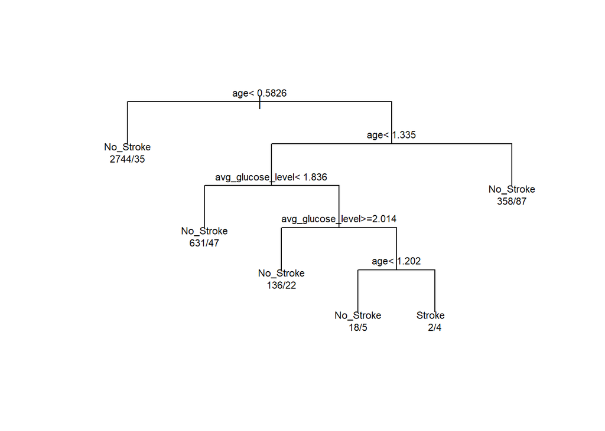

```r
# We are plotting the decision tree only if the model actually created splits.
if (any(decision_tree_model$frame$var != "<leaf>")) {
  plot(decision_tree_model, uniform = TRUE, margin = 0.1)
  text(decision_tree_model, use.n = TRUE, cex = 0.7)
} else {
  cat("The Decision Tree did not create any split. It remained only a root node.
")
}
```

# 35. Decision Tree Prediction and Evaluation

Now we test the Decision Tree model using the same testing dataset.

```r
# Predict classes for the test data using Decision Tree.
dt_predicted_class <- predict(decision_tree_model,
                              newdata = test_data,
                              type = "class")

# Making sure predicted class levels match the actual target levels.
dt_predicted_class <- factor(dt_predicted_class, levels = c("No_Stroke", "Stroke"))

# Showing first few predicted classes
head(dt_predicted_class)
```

```
##         2        15        16        19        20        22
## No_Stroke No_Stroke No_Stroke No_Stroke No_Stroke No_Stroke
## Levels: No_Stroke Stroke
```

```r
# Confusion matrix for Decision Tree.
dt_conf_matrix <- confusionMatrix(dt_predicted_class, test_data$stroke, positive = "Stroke")
dt_conf_matrix
```

```
## Confusion Matrix and Statistics
##
##            Reference
## Prediction  No_Stroke Stroke
##   No_Stroke       972     49
##   Stroke            0      0
##
##                Accuracy : 0.952
##                  95% CI : (0.937, 0.9643)
##     No Information Rate : 0.952
##     P-Value [Acc > NIR] : 0.5379
##
##                   Kappa : 0
##
##  Mcnemar's Test P-Value : 7.025e-12
##
##             Sensitivity : 0.00000
##             Specificity : 1.00000
##          Pos Pred Value :     NaN
##          Neg Pred Value : 0.95201
##              Prevalence : 0.04799
##          Detection Rate : 0.00000
##    Detection Prevalence : 0.00000
##       Balanced Accuracy : 0.50000
##
##        'Positive' Class : Stroke
##
```

```r
# Accuracy
dt_accuracy <- dt_conf_matrix$overall["Accuracy"]

# Precision and Recall
dt_precision <- dt_conf_matrix$byClass["Precision"]
dt_recall <- dt_conf_matrix$byClass["Recall"]


if(is.na(dt_precision)) dt_precision <- 0
if(is.na(dt_recall)) dt_recall <- 0

# F1-score
if((dt_precision + dt_recall) == 0){
  dt_f1_score <- 0
} else {
  dt_f1_score <- 2 * ((dt_precision * dt_recall) / (dt_precision + dt_recall))
}

# Final metric table for Decision Tree
dt_evaluation_results <- data.frame(
  Model = "Decision Tree",
  Accuracy = as.numeric(dt_accuracy),
  Precision = as.numeric(dt_precision),
  Recall = as.numeric(dt_recall),
  F1_Score = as.numeric(dt_f1_score)
)

dt_evaluation_results
```

```
##           Model  Accuracy Precision Recall F1_Score
## 1 Decision Tree 0.9520078         0      0        0
```

# 36. Comparison of Logistic Regression and Decision Tree

This section compares Logistic Regression with the standard 0.50 threshold, Logistic Regression with a lower 0.30 threshold, and Decision Tree using the same evaluation metrics: Accuracy, Precision, Recall, and F1-score.

```r
# Renaming the first Logistic Regression
evaluation_results$Model <- "Logistic Regression 0.50 Threshold"

# Combining all model results into one comparison table.
model_comparison <- rbind(evaluation_results, evaluation_results_030, dt_evaluation_results)

# Print comparison table
model_comparison
```

```
##                                Model  Accuracy Precision     Recall   F1_Score
## 1 Logistic Regression 0.50 Threshold 0.9520078 0.0000000 0.00000000 0.00000000
## 2 Logistic Regression 0.30 Threshold 0.9490695 0.2857143 0.04081633 0.07142857
## 3                      Decision Tree 0.9520078 0.0000000 0.00000000 0.00000000
```

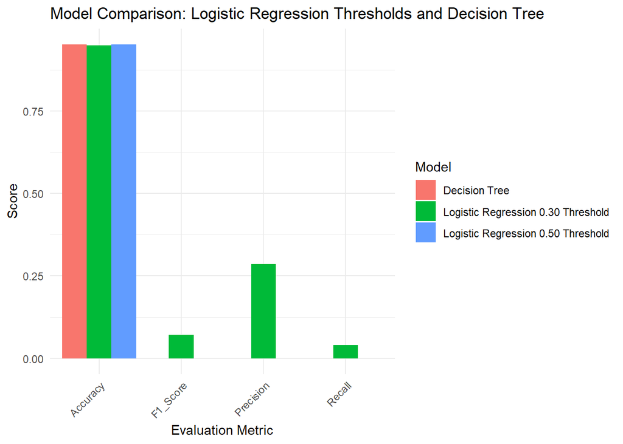

```r
# Bar plot for visual comparison of the models.
comparison_long <- data.frame(
  Model = rep(model_comparison$Model, times = 4),
  Metric = rep(c("Accuracy", "Precision", "Recall", "F1_Score"), each = nrow(model_comparison)),
  Value = c(model_comparison$Accuracy,
            model_comparison$Precision,
            model_comparison$Recall,
            model_comparison$F1_Score)
)

ggplot(comparison_long, aes(x = Metric, y = Value, fill = Model)) +
  geom_bar(stat = "identity", position = "dodge") +
  labs(title = "Model Comparison: Logistic Regression Thresholds and Decision Tree",
       x = "Evaluation Metric",
       y = "Score") +
  theme_minimal() +
  theme(axis.text.x = element_text(angle = 45, hjust = 1))
```

The comparison table shows how the models perform on the same test data. Accuracy shows overall correctness, while Precision, Recall, and F1-score are more important for understanding how well the model detects the minority class, Stroke. In an imbalanced dataset such as this one, the standard 0.50 threshold gave high accuracy but failed to detect Stroke cases. The lower 0.30 threshold is checked to see whether recall and F1-score improve and it showed improved results.

## 37.1 Confusion Matrix Heatmaps

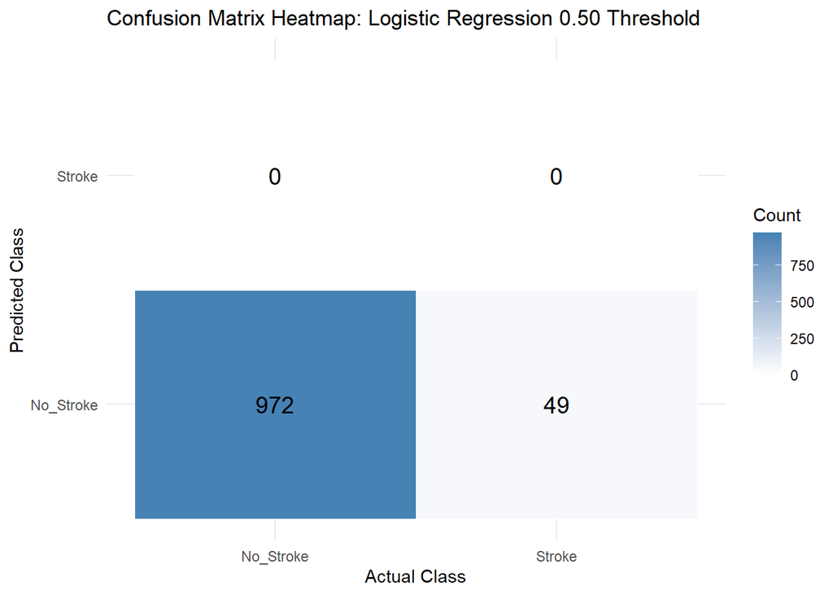

```r
# This function converts a confusion matrix into a heatmap.
plot_confusion_heatmap <- function(conf_object, model_name){
  cm_table <- as.data.frame(conf_object$table)
  colnames(cm_table) <- c("Prediction", "Actual", "Count")

  ggplot(cm_table, aes(x = Actual, y = Prediction, fill = Count)) +
    geom_tile(color = "white") +
    geom_text(aes(label = Count), size = 5) +
    scale_fill_gradient(low = "white", high = "steelblue") +
    labs(title = paste("Confusion Matrix Heatmap:", model_name),
         x = "Actual Class",
         y = "Predicted Class") +
    theme_minimal()
}

# plotting Confusion matrix heatmap for Logistic Regression with 0.50 threshold.
plot_confusion_heatmap(conf_matrix, "Logistic Regression 0.50 Threshold")
```

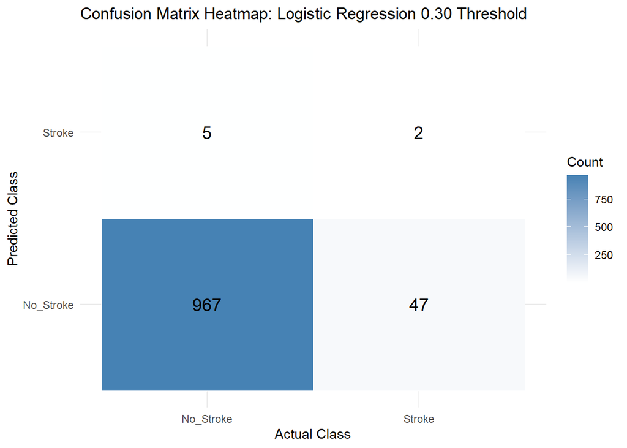

```r
# Confusion matrix heatmap for Logistic Regression with 0.30 threshold.
plot_confusion_heatmap(conf_matrix_030, "Logistic Regression 0.30 Threshold")
```

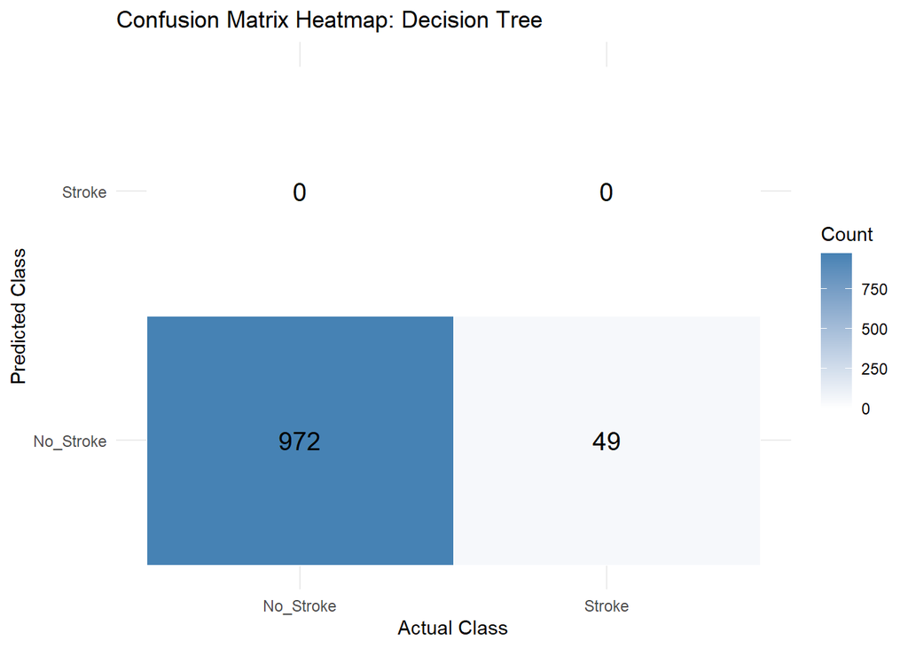

```r
# Confusion matrix heatmap for Decision Tree.
plot_confusion_heatmap(dt_conf_matrix, "Decision Tree")
```

The heatmaps make the confusion matrix easier to understand visually. The diagonal cells show correct predictions, while the off-diagonal cells show incorrect predictions.

## 37.2 Improved Model Comparison Visualization

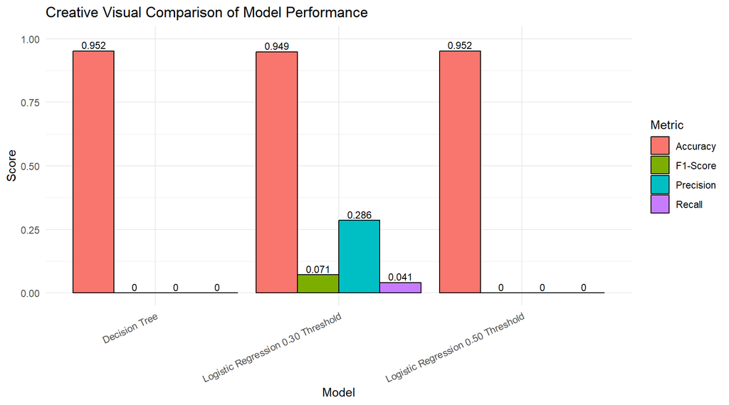

```r
# Converting the model comparison table into long format for better visualization.
comparison_visual <- data.frame(
  Model = rep(model_comparison$Model, each = 4),
  Metric = rep(c("Accuracy", "Precision", "Recall", "F1-Score"), times = nrow(model_comparison)),
  Score = as.vector(t(model_comparison[, c("Accuracy", "Precision", "Recall", "F1_Score")]))
)

# Bar chart comparing all models across all evaluation metrics.
ggplot(comparison_visual, aes(x = Model, y = Score, fill = Metric)) +
  geom_col(position = "dodge", color = "black") +
  geom_text(aes(label = round(Score, 3)),
            position = position_dodge(width = 0.9),
            vjust = -0.3,
            size = 3) +
  labs(title = "Creative Visual Comparison of Model Performance",
       x = "Model",
       y = "Score") +
  coord_cartesian(ylim = c(0, 1)) +
  theme_minimal() +
  theme(axis.text.x = element_text(angle = 25, hjust = 1))
```

This visualization compares the models more clearly than a table alone. It shows that accuracy may be high, but precision, recall, and F1-score are more useful for judging how well the models detect the minority **Stroke** class.

# 38. Final Insights and Conclusion

The dataset was successfully loaded from google drive, but it was previously downloaded from Kaggle. The dataset was then explored, cleaned, preprocessed, and used for classification modeling. The EDA showed that age, BMI, and average glucose level are useful health-related variables for understanding stroke risk. Missing BMI values were handled using median imputation, and BMI outliers were handled using the IQR method.

The target variable was imbalanced because the number of non-stroke cases was much higher than the number of stroke cases. Because of this imbalance, accuracy alone may not be enough to judge the model. Therefore, precision, recall, and F1-score were also calculated.

Two classification models were built and tested using the same 80-20 train-test split: Logistic Regression and Decision Tree. Logistic Regression was used as the main baseline model because it is suitable for binary classification. The standard Logistic Regression threshold of 0.50 was tested first. Then a lower threshold of 0.30 was also tested to make the model more sensitive to the minority Stroke class. Decision Tree was added as a second model because it can capture rule-based and non-linear relationships.

The comparison table helps show that high accuracy can be misleading in an imbalanced classification problem. For stroke prediction, recall and F1-score are especially important because the goal is to correctly identify actual Stroke cases. Overall, the project is following the complete data science lifecycle: data collection, exploration, preprocessing, modeling, evaluation, model comparison, and interpretation.